# KNN Project Solution

Since KNN is such a simple algorithm, we will just use this "Project" as a simple exercise to test your understanding of the implementation of KNN. By now you should feel comfortable implementing a machine learning algorithm in R, as long as you know what library to use for it.

So for this project, just follow along with the bolded instructions. It should be very simple, so at the end you'll have an additional optional "bonus" project.

## Iris Data Set

We'll use the famous [iris](https://en.wikipedia.org/wiki/Iris_flower_data_set) data set for this project. It's a small data set with flower features that can be used to attempt to predict the species of an iris flower.

**Use the ISLR libary to get the iris data set. Check the head of the iris Data Frame.**

```r
library(ISLR)
```

```r
head(iris)
```

|  | Sepal.Length | Sepal.Width | Petal.Length | Petal.Width | Species |
| --- | --- | --- | --- | --- | --- |
| 1 | 5.1 | 3.5 | 1.4 | 0.2 | setosa |
| 2 | 4.9 | 3 | 1.4 | 0.2 | setosa |
| 3 | 4.7 | 3.2 | 1.3 | 0.2 | setosa |
| 4 | 4.6 | 3.1 | 1.5 | 0.2 | setosa |
| 5 | 5 | 3.6 | 1.4 | 0.2 | setosa |
| 6 | 5.4 | 3.9 | 1.7 | 0.4 | setosa |

```r
str(iris)
```

```
'data.frame':	150 obs. of  5 variables:
 $ Sepal.Length: num  5.1 4.9 4.7 4.6 5 5.4 4.6 5 4.4 4.9 ...
 $ Sepal.Width : num  3.5 3 3.2 3.1 3.6 3.9 3.4 3.4 2.9 3.1 ...
 $ Petal.Length: num  1.4 1.4 1.3 1.5 1.4 1.7 1.4 1.5 1.4 1.5 ...
 $ Petal.Width : num  0.2 0.2 0.2 0.2 0.2 0.4 0.3 0.2 0.2 0.1 ...
 $ Species     : Factor w/ 3 levels "setosa","versicolor",..: 1 1 1 1 1 1 1 1 1 1 ...
```

## Standardize Data

In this case, the iris data set has all its features in the same order of magnitude, but its good practice (especially with KNN) to standardize features in your data. Lets go ahead and do this even though its not necessary for this data!

**Use scale() to standardize the feature columns of the iris dataset. Set this standardized version of the data as a new variable.**

```r
stand.features <- scale(iris[1:4])
```

**Check that the scaling worked by checking the variance of one of the new columns.**

```r
var(stand.features[,1])
```

1

**Join the standardized data with the response/target/label column (the column with the species names.**

```r
final.data <- cbind(stand.features,iris[5])
```

```r
head(final.data)
```

|  | Sepal.Length | Sepal.Width | Petal.Length | Petal.Width | Species |
| --- | --- | --- | --- | --- | --- |
| 1 | -0.8976739 | 1.015602 | -1.335752 | -1.311052 | setosa |
| 2 | -1.1392 | -0.1315388 | -1.335752 | -1.311052 | setosa |
| 3 | -1.380727 | 0.3273175 | -1.392399 | -1.311052 | setosa |
| 4 | -1.50149 | 0.09788935 | -1.279104 | -1.311052 | setosa |
| 5 | -1.018437 | 1.24503 | -1.335752 | -1.311052 | setosa |
| 6 | -0.535384 | 1.933315 | -1.165809 | -1.048667 | setosa |

## Train and Test Splits

**Use the caTools library to split your standardized data into train and test sets. Use a 70/30 split.**

```r
set.seed(101)

library(caTools)

sample <- sample.split(final.data$Species, SplitRatio = .70)
train <- subset(final.data, sample == TRUE)
test <- subset(final.data, sample == FALSE)
```

## Build a KNN model.

**Call the class library.**

```r
library(class)
```

**Use the knn function to predict Species of the test set. Use k=1**

```r
predicted.species <- knn(train[1:4],test[1:4],train$Species,k=1)
```

```r
predicted.species
```

1. setosa

2. setosa

3. setosa

4. setosa

5. setosa

6. setosa

7. setosa

8. setosa

9. setosa

10. setosa

11. setosa

12. setosa

13. setosa

14. setosa

15. setosa

16. versicolor

17. versicolor

18. versicolor

19. versicolor

20. versicolor

21. virginica

22. versicolor

23. versicolor

24. versicolor

25. versicolor

26. versicolor

27. virginica

28. versicolor

29. versicolor

30. versicolor

31. virginica

32. virginica

33. virginica

34. virginica

35. virginica

36. virginica

37. virginica

38. virginica

39. virginica

40. virginica

41. virginica

42. virginica

43. virginica

44. virginica

45. virginica

**What was your misclassification rate?**

```r
mean(test$Species != predicted.species)
```

0.0444444444444444

## Choosing a K Value

Although our data is quite small for us to really get a feel for choosing a good K value, let's practice.

**Create a plot of the error (misclassification) rate for k values ranging from 1 to 10.**

```r
predicted.species <- NULL
error.rate <- NULL

for(i in 1:10){
    set.seed(101)
    predicted.species <- knn(train[1:4],test[1:4],train$Species,k=i)
    error.rate[i] <- mean(test$Species != predicted.species)
}
```

```r
library(ggplot2)
k.values <- 1:10
error.df <- data.frame(error.rate,k.values)
```

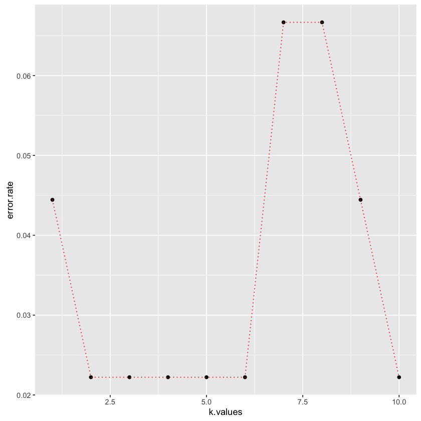

```r
pl <- ggplot(error.df,aes(x=k.values,y=error.rate)) + geom_point()
pl + geom_line(lty="dotted",color='red')
```

**You should have noticed that the error drops to its lowest for k values between 2-6. Then it begins to jump back up again, this is due to how small the data set it. At k=10 you begin to approach setting k=10% of the data, which is quite large.**

## Optional Assignment

You should feel pretty comfortable using KNN since its so simple. As an optional assignment, choose a data set from the UCI Machine Learning Repository and see if you can use the process laid out above to do your own classification!

[Check out the data sets here](http://archive.ics.uci.edu/ml/)